# PCA

Group 7

2024-05-20

# 1 Data preparation

```r
df <- read_excel("df_definitivo.xlsx", sheet= "datos")

df$SII_pre = log(df$SII_pre)
df$SII_1C = log(df$SII_1C)
df$SII_2C = log(df$SII_2C)
df$SII_1eval = log(df$SII_1eval)

#summary(df)
descDatos = data.frame("variable" = colnames(df),
                       "tipo" = c(rep("categorical",2),"numerical",rep("categorical",2),rep("numerical",5),rep("categorical",5),rep("numerical",34), "categorical",
                                  rep("numerical",3), "categorical",rep("numerical",11),"categorical", "numerical", rep("categorical",5), "numerical", "categorical",
                                  "numerical",rep("categorical",17)))
rownames(descDatos) = descDatos$variable
```

# 2 Selection of the number of PCs

We generate the PCA model for all possible principal components (or a high number of them) and select the “optimal” number of principal components (PCs). We will apply centering and scaling within the PCA function itself

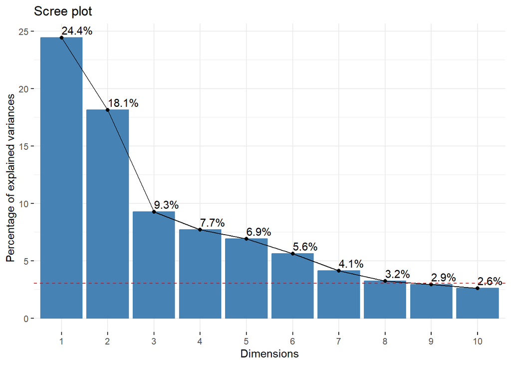

```r
res.pca = PCA(df, scale.unit = TRUE, graph = FALSE, ncp = 10,
              quali.sup = which(descDatos$tipo == "categorical"))
eig.val <- get_eigenvalue(res.pca)
VPmedio = 100 * (1/nrow(eig.val))
fviz_eig(res.pca, addlabels = TRUE) +
  geom_hline(yintercept=VPmedio, linetype=2, color="red")
```

```r
kable(eig.val[1:6,])
```

|  | eigenvalue | variance.percent | cumulative.variance.percent |
| --- | --- | --- | --- |
| Dim.1 | 13.936002 | 24.449127 | 24.44913 |
| Dim.2 | 10.336762 | 18.134670 | 42.58380 |
| Dim.3 | 5.286933 | 9.275321 | 51.85912 |
| Dim.4 | 4.396477 | 7.713118 | 59.57224 |
| Dim.5 | 3.946082 | 6.922951 | 66.49519 |
| Dim.6 | 3.206010 | 5.624580 | 72.11977 |

```r
K = 5
res.pca = PCA(df, scale.unit = TRUE, graph = FALSE, ncp = K,
              quali.sup = which(descDatos$tipo == "categorical"))
```

Starting from the model with 10 components, we select the most appropriate number of principal components (PCs) using the elbow method but choosing two components more for explain more variability. We select 5 PCs, which explain 66.5% of the total variability of the data.